# Search: Solving a Maze Using a Goal-based Agent

### A* search BFS open maze

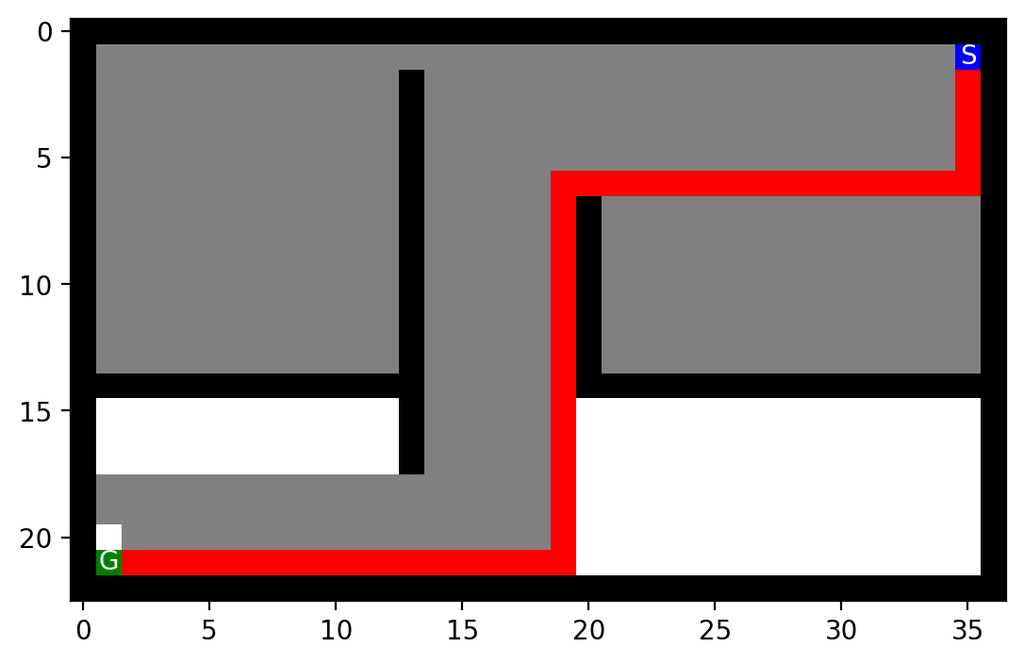

|  | Algorithm | Path Cost | Nodes Expanded | Max Tree Depth | Max Frontier Size | max memory usage |
| --- | --- | --- | --- | --- | --- | --- |
| 0 | A_BFS | 54 | 534 | 54 | 25 | 576 |

```python
class Node:
    def __init__(self, pos, parent=None, action=None, cost=0, h=0):
        self.pos = tuple(pos)    # the state; positions are (row, col)
        self.parent = parent     # reference to parent node. None means root node.
        self.action = action     # action used in the transition function (root node has None)
        self.cost = cost         # for uniform cost this is the depth. It is also g(n) for A* search
        self.h = h               # for Manhattan distance
        self.f = self.cost + self.h  # f(n) = g(n) + h(n), A* search uses this

    def __str__(self):
        return f"Node - pos = {self.pos}; action = {self.action}; cost = {self.cost}"

    def get_path_from_root(self):
        """Returns nodes on the path from the root to the current node."""
        node = self
        path = [node]

        while node.parent is not None:
            node = node.parent
            path.append(node)

        path.reverse()
        return path

def manhattan_distance(pos, goal):
    """Calculate the Manhattan distance from current position to goal."""
    return abs(pos[0] - goal[0]) + abs(pos[1] - goal[1])

def sorting(frontier, node):
    """Insert the node into the frontier, maintaining the list sorted by heuristic h(n)."""
    inserted = False
    for i in range(len(frontier)):
        if node.f < frontier[i].f:
            frontier.insert(i, node)
            inserted = True
            break
    if not inserted:
        frontier.append(node)  # Insert at the end if not inserted earlier

ACTIONS = [(-1, 0, 'North'), (1, 0, 'South'), (0, -1, 'West'), (0, 1, 'East')]

def mark_maze(maze, pos, symbol):
    """Marks the maze at a given position with a symbol."""
    maze[pos[0]][pos[1]] = symbol

def A_BFS(maze, start, goal):
    # Initialize the initial node and check if it's the goal
    initial_node = Node(pos=start, h=manhattan_distance(start, goal))
    if start == goal:  # Check if the initial state is the goal
        return initial_node.get_path_from_root(), 0, 0, 0, 0


    # Initialize the frontier (FIFO queue) and reached set
    frontier = [initial_node]  # Frontier initialized with the initial node
    reached = set()  # Reached set to track visited nodes
    reached.add(start)
    nodes_expanded = 0  # Total number of nodes expanded
    max_tree_depth = 0  # Maximum depth of the search tree
    max_frontier_size = 1  # Maximum size of the frontier
    max_memory_usage = 1  # Maximum number of nodes in memory (frontier + reached)

    # Loop until we either find the goal or exhaust the frontier
    while frontier:

        node = frontier.pop(0)
        nodes_expanded += 1  # Count this node as expanded
        if maze[node.pos[0]][node.pos[1]] != 'S':
            mark_maze(maze, node.pos, '.')

        # Explore neighboring nodes (possible actions)
        for dx, dy, action in ACTIONS:
            next_pos = (node.pos[0] + dx, node.pos[1] + dy)  # Next position
            if maze[next_pos[0]][next_pos[1]] != 'X' and next_pos not in reached:
                reached.add(next_pos)

                # Create child nodes
                child = Node(next_pos, node, action, node.cost + 1, h=manhattan_distance(next_pos, goal))  # Child branch
                sorting(frontier, child)
                max_tree_depth = max(max_tree_depth, child.cost)
                max_frontier_size = max(max_frontier_size, len(frontier))

                if maze[next_pos[0]][next_pos[1]] == 'G':
                    solution_path = child.get_path_from_root()
                    path_cost = len(solution_path) - 1
                    for path_node in solution_path:
                        if maze[path_node.pos[0]][path_node.pos[1]] not in ['G', 'S']:
                            mark_maze(maze, path_node.pos, 'P')
                            clear_output(wait=True)
                            mh.show_maze(maze)
                    return solution_path, path_cost, nodes_expanded, max_tree_depth, max_frontier_size,max_memory_usage

        max_memory_usage = max(max_memory_usage, len(frontier) + len(reached))
        clear_output(wait=True)
        mh.show_maze(maze)

    return None
with open("open_maze.txt", "r") as f:
    maze_str = f.read()
maze = mh.parse_maze(maze_str)
start= mh.find_pos(maze, what = "S")
goal= mh.find_pos(maze, what = "G")
print('start point is',start,'goal point is',goal)


[solution_path,ABFS_open_path_cost,ABFS_open_nodes_expanded,ABFS_open_max_tree_depth, ABFS_open_max_frontier_size,ABFS_open_memory_usage] =  A_BFS(maze, start, goal)
data = {
    'Algorithm': ['A_BFS'],
    'Path Cost': [ABFS_open_path_cost],
    'Nodes Expanded': [ABFS_open_nodes_expanded],
    'Max Tree Depth': [ABFS_open_max_tree_depth],
    'Max Frontier Size': [ABFS_open_max_frontier_size],
    'max memory usage':[ABFS_open_memory_usage]
}

# Create a DataFrame
df = pd.DataFrame(data)
df
```

Are your implementations complete and optimal? What is the time and space complexity?

both Greedy-BFS and A*-BFS are complete. the Greedy-BFS is not optimal but A* is optimal. Time complexity for Greedy-BFS is O(bm) in best case and O(b^m) in worst case Space complexity for Greedy-BFS is O(bm) in best case and O(b^m) in worst case Time complexity for A*-BFS is equal to number of nodes space complexity for A*-BFS is equal to number of nodes

## Task 4: Comparison and discussion [20 Points]

Run experiments to compare the implemented algorithms.

How to deal with issues:

- Your implementation returns unexpected results: Try to debug and fix the code. Visualizing the maze, the current path and the frontier after every step is very helpful. If the code still does not work, then mark the result with an asterisk (*) and describe the issue below the table.
- Your implementation cannot consistently solve a specific maze and ends up in an infinite loop: Debug (likely your frontier and cycle checking for DFS are the issue). If it is a shortcoming of the algorithm/implementation, then put "N/A*" in the results table and describe why this is happening.

Complete the following table for each maze.

**Small maze**

```python
import pandas as pd

# Create a dictionary with the data for each algorithm (initialize as empty or zero)
data = {
    'Algorithm': ['BFS', 'DFS', 'GBS', 'A*'],
    'Path Cost': [BFS_small_path_cost,DFS_small_path_cost, GBFS_small_path_cost, ABFS_small_path_cost],
    '# of Nodes Expanded': [BFS_small_nodes_expanded, DFS_small_nodes_expanded, GBFS_small_nodes_expanded, ABFS_small_nodes_expanded],
    'Max Tree Depth': [BFS_small_max_tree_depth, DFS_small_max_tree_depth, GBFS_small_max_tree_depth, ABFS_small_max_tree_depth],
    'Max # of Nodes in Memory': [BFS_small_memory_usage, DFS_small_memory_usage, GBFS_small_memory_usage, ABFS_small_memory_usage],
    'Max Frontier Size': [BFS_small_max_frontier_size, DFS_small_max_frontier_size, GBFS_small_max_frontier_size, ABFS_small_max_frontier_size]
}

# Create a DataFrame from the dictionary
df_small = pd.DataFrame(data)

# Display the DataFrame
df_small
```

|  | Algorithm | Path Cost | # of Nodes Expanded | Max Tree Depth | Max # of Nodes in Memory | Max Frontier Size |
| --- | --- | --- | --- | --- | --- | --- |
| 0 | BFS | 19 | 90 | 19 | 94 | 8 |
| 1 | DFS | 37 | 37 | 36 | 43 | 7 |
| 2 | GBS | 29 | 39 | 29 | 90 | 48 |
| 3 | A* | 19 | 52 | 19 | 65 | 8 |

**Medium maze**

```python
import pandas as pd

# Create a dictionary with the data for each algorithm (initialize as empty or zero)
data = {
    'Algorithm': ['BFS', 'DFS', 'GBS', 'A*'],
    'Path Cost': [BFS_medium_path_cost,DFS_medium_path_cost, GBFS_medium_path_cost, ABFS_medium_path_cost],
    '# of Nodes Expanded': [BFS_medium_nodes_expanded, DFS_medium_nodes_expanded, GBFS_medium_nodes_expanded, ABFS_medium_nodes_expanded],
    'Max Tree Depth': [BFS_medium_max_tree_depth, DFS_medium_max_tree_depth, GBFS_medium_max_tree_depth, ABFS_medium_max_tree_depth],
    'Max # of Nodes in Memory': [BFS_medium_memory_usage, DFS_medium_memory_usage, GBFS_medium_memory_usage, ABFS_medium_memory_usage],
    'Max Frontier Size': [BFS_medium_max_frontier_size, DFS_medium_max_frontier_size, GBFS_medium_max_frontier_size, ABFS_medium_max_frontier_size]
}

# Create a DataFrame from the dictionary
df_medium = pd.DataFrame(data)

# Display the DataFrame
df_medium
```

|  | Algorithm | Path Cost | # of Nodes Expanded | Max Tree Depth | Max # of Nodes in Memory | Max Frontier Size |
| --- | --- | --- | --- | --- | --- | --- |
| 0 | BFS | 68 | 267 | 68 | 272 | 8 |
| 1 | DFS | 130 | 146 | 129 | 154 | 9 |
| 2 | GBS | 74 | 78 | 74 | 165 | 85 |
| 3 | A* | 68 | 221 | 68 | 234 | 8 |

**large maze**

```python
import pandas as pd

# Create a dictionary with the data for each algorithm (initialize as empty or zero)
data = {
    'Algorithm': ['BFS', 'DFS', 'GBS', 'A*'],
    'Path Cost': [BFS_large_path_cost,DFS_large_path_cost, GBFS_large_path_cost, ABFS_large_path_cost],
    '# of Nodes Expanded': [BFS_large_nodes_expanded, DFS_large_nodes_expanded, GBFS_large_nodes_expanded, ABFS_large_nodes_expanded],
    'Max Tree Depth': [BFS_large_max_tree_depth, DFS_large_max_tree_depth, GBFS_large_max_tree_depth, ABFS_large_max_tree_depth],
    'Max # of Nodes in Memory': [BFS_large_memory_usage, DFS_large_memory_usage, GBFS_large_memory_usage, ABFS_large_memory_usage],
    'Max Frontier Size': [BFS_large_max_frontier_size, DFS_large_max_frontier_size, GBFS_large_max_frontier_size, ABFS_large_max_frontier_size]
}

# Create a DataFrame from the dictionary
df_large = pd.DataFrame(data)

# Display the DataFrame
df_large
```

|  | Algorithm | Path Cost | # of Nodes Expanded | Max Tree Depth | Max # of Nodes in Memory | Max Frontier Size |
| --- | --- | --- | --- | --- | --- | --- |
| 0 | BFS | 210 | 617 | 210 | 624 | 8 |
| 1 | DFS | 210 | 387 | 222 | 425 | 39 |
| 2 | GBS | 210 | 668 | 210 | 790 | 305 |
| 3 | A* | 210 | 549 | 210 | 564 | 12 |

**wall maze**

```python
import pandas as pd

# Create a dictionary with the data for each algorithm (initialize as empty or zero)
data = {
    'Algorithm': ['BFS', 'DFS', 'GBS', 'A*'],
    'Path Cost': [BFS_wall_path_cost,DFS_wall_path_cost, GBFS_wall_path_cost, ABFS_wall_path_cost],
    '# of Nodes Expanded': [BFS_wall_nodes_expanded, DFS_wall_nodes_expanded, GBFS_wall_nodes_expanded, ABFS_wall_nodes_expanded],
    'Max Tree Depth': [BFS_wall_max_tree_depth, DFS_wall_max_tree_depth, GBFS_wall_max_tree_depth, ABFS_wall_max_tree_depth],
    'Max # of Nodes in Memory': [BFS_wall_memory_usage, DFS_wall_memory_usage, GBFS_wall_memory_usage, ABFS_wall_memory_usage],
    'Max Frontier Size': [BFS_wall_max_frontier_size, DFS_wall_max_frontier_size, GBFS_wall_max_frontier_size, ABFS_wall_max_frontier_size]
}

# Create a DataFrame from the dictionary
df_wall = pd.DataFrame(data)

# Display the DataFrame
df_wall
```

|  | Algorithm | Path Cost | # of Nodes Expanded | Max Tree Depth | Max # of Nodes in Memory | Max Frontier Size |
| --- | --- | --- | --- | --- | --- | --- |
| 0 | BFS | 14 | 85 | 14 | 92 | 11 |
| 1 | DFS | 44 | 44 | 43 | 79 | 36 |
| 2 | GBS | 14 | 14 | 14 | 106 | 71 |
| 3 | A* | 14 | 55 | 14 | 114 | 31 |

**loops maze**

```python
import pandas as pd

# Create a dictionary with the data for each algorithm (initialize as empty or zero)
data = {
    'Algorithm': ['BFS', 'DFS', 'GBS', 'A*'],
    'Path Cost': [BFS_loops_path_cost,DFS_loops_path_cost, GBFS_loops_path_cost, ABFS_loops_path_cost],
    '# of Nodes Expanded': [BFS_loops_nodes_expanded, DFS_loops_nodes_expanded, GBFS_loops_nodes_expanded, ABFS_loops_nodes_expanded],
    'Max Tree Depth': [BFS_loops_max_tree_depth, DFS_loops_max_tree_depth, GBFS_loops_max_tree_depth, ABFS_loops_max_tree_depth],
    'Max # of Nodes in Memory': [BFS_loops_memory_usage, DFS_loops_memory_usage, GBFS_loops_memory_usage, ABFS_loops_memory_usage],
    'Max Frontier Size': [BFS_loops_max_frontier_size, DFS_loops_max_frontier_size, GBFS_loops_max_frontier_size, ABFS_loops_max_frontier_size]
}

# Create a DataFrame from the dictionary
df_loops = pd.DataFrame(data)

# Display the DataFrame
df_loops
```

|  | Algorithm | Path Cost | # of Nodes Expanded | Max Tree Depth | Max # of Nodes in Memory | Max Frontier Size |
| --- | --- | --- | --- | --- | --- | --- |
| 0 | BFS | 23 | 70 | 23 | 73 | 8 |
| 1 | DFS | 27 | 30 | 26 | 41 | 12 |
| 2 | GBS | 23 | 85 | 23 | 92 | 36 |
| 3 | A* | 23 | 57 | 23 | 66 | 6 |

**empty maze**

```python
import pandas as pd

# Create a dictionary with the data for each algorithm (initialize as empty or zero)
data = {
    'Algorithm': ['BFS', 'DFS', 'GBS', 'A*'],
    'Path Cost': [BFS_empty_path_cost,DFS_empty_path_cost, GBFS_empty_path_cost, ABFS_empty_path_cost],
    '# of Nodes Expanded': [BFS_empty_nodes_expanded, DFS_empty_nodes_expanded, GBFS_empty_nodes_expanded, ABFS_empty_nodes_expanded],
    'Max Tree Depth': [BFS_empty_max_tree_depth, DFS_empty_max_tree_depth, GBFS_empty_max_tree_depth, ABFS_empty_max_tree_depth],
    'Max # of Nodes in Memory': [BFS_empty_memory_usage, DFS_empty_memory_usage, GBFS_empty_memory_usage, ABFS_empty_memory_usage],
    'Max Frontier Size': [BFS_empty_max_frontier_size, DFS_empty_max_frontier_size, GBFS_empty_max_frontier_size, ABFS_empty_max_frontier_size]
}

# Create a DataFrame from the dictionary
df_empty = pd.DataFrame(data)

# Display the DataFrame
df_empty
```

|  | Algorithm | Path Cost | # of Nodes Expanded | Max Tree Depth | Max # of Nodes in Memory | Max Frontier Size |
| --- | --- | --- | --- | --- | --- | --- |
| 0 | BFS | 14 | 92 | 14 | 99 | 12 |
| 1 | DFS | 72 | 72 | 71 | 136 | 65 |
| 2 | GBS | 14 | 14 | 14 | 106 | 71 |
| 3 | A* | 14 | 62 | 14 | 121 | 31 |

**empty_2 maze**

```python
import pandas as pd

# Create a dictionary with the data for each algorithm (initialize as empty or zero)
data = {
    'Algorithm': ['BFS', 'DFS', 'GBS', 'A*'],
    'Path Cost': [BFS_empty_2_path_cost,DFS_empty_2_path_cost, GBFS_empty_2_path_cost, ABFS_empty_2_path_cost],
    '# of Nodes Expanded': [BFS_empty_2_nodes_expanded, DFS_empty_2_nodes_expanded, GBFS_empty_2_nodes_expanded, ABFS_empty_2_nodes_expanded],
    'Max Tree Depth': [BFS_empty_2_max_tree_depth, DFS_empty_2_max_tree_depth, GBFS_empty_2_max_tree_depth, ABFS_empty_2_max_tree_depth],
    'Max # of Nodes in Memory': [BFS_empty_2_memory_usage, DFS_empty_2_memory_usage, GBFS_empty_2_memory_usage, ABFS_empty_2_memory_usage],
    'Max Frontier Size': [BFS_empty_2_max_frontier_size, DFS_empty_2_max_frontier_size, GBFS_empty_2_max_frontier_size, ABFS_empty_2_max_frontier_size]
}

# Create a DataFrame from the dictionary
df_empty_2 = pd.DataFrame(data)

# Display the DataFrame
df_empty_2
```

|  | Algorithm | Path Cost | # of Nodes Expanded | Max Tree Depth | Max # of Nodes in Memory | Max Frontier Size |
| --- | --- | --- | --- | --- | --- | --- |
| 0 | BFS | 14 | 92 | 14 | 99 | 12 |
| 1 | DFS | 54 | 54 | 53 | 112 | 59 |
| 2 | GBS | 14 | 14 | 14 | 106 | 71 |
| 3 | A* | 14 | 62 | 14 | 121 | 31 |

**open maze**

```python
import pandas as pd

# Create a dictionary with the data for each algorithm (initialize as empty or zero)
data = {
    'Algorithm': ['BFS', 'DFS', 'GBS', 'A*'],
    'Path Cost': [BFS_open_path_cost,DFS_open_path_cost, GBFS_open_path_cost, ABFS_open_path_cost],
    '# of Nodes Expanded': [BFS_open_nodes_expanded, DFS_open_nodes_expanded, GBFS_open_nodes_expanded, ABFS_open_nodes_expanded],
    'Max Tree Depth': [BFS_open_max_tree_depth, DFS_open_max_tree_depth, GBFS_open_max_tree_depth, ABFS_open_max_tree_depth],
    'Max # of Nodes in Memory': [BFS_open_memory_usage, DFS_open_memory_usage, GBFS_open_memory_usage, ABFS_open_memory_usage],
    'Max Frontier Size': [BFS_open_max_frontier_size, DFS_open_max_frontier_size, GBFS_open_max_frontier_size, ABFS_open_max_frontier_size]
}

# Create a DataFrame from the dictionary
df_open = pd.DataFrame(data)

# Display the DataFrame
df_open
```

|  | Algorithm | Path Cost | # of Nodes Expanded | Max Tree Depth | Max # of Nodes in Memory | Max Frontier Size |
| --- | --- | --- | --- | --- | --- | --- |
| 0 | BFS | 54 | 679 | 54 | 687 | 25 |
| 1 | DFS | 330 | 7595 | 329 | 936 | 329 |
| 2 | GBS | 68 | 89 | 68 | 370 | 220 |
| 3 | A* | 54 | 534 | 54 | 576 | 25 |

Present the results as using charts (see Python Code Examples/charts and tables).

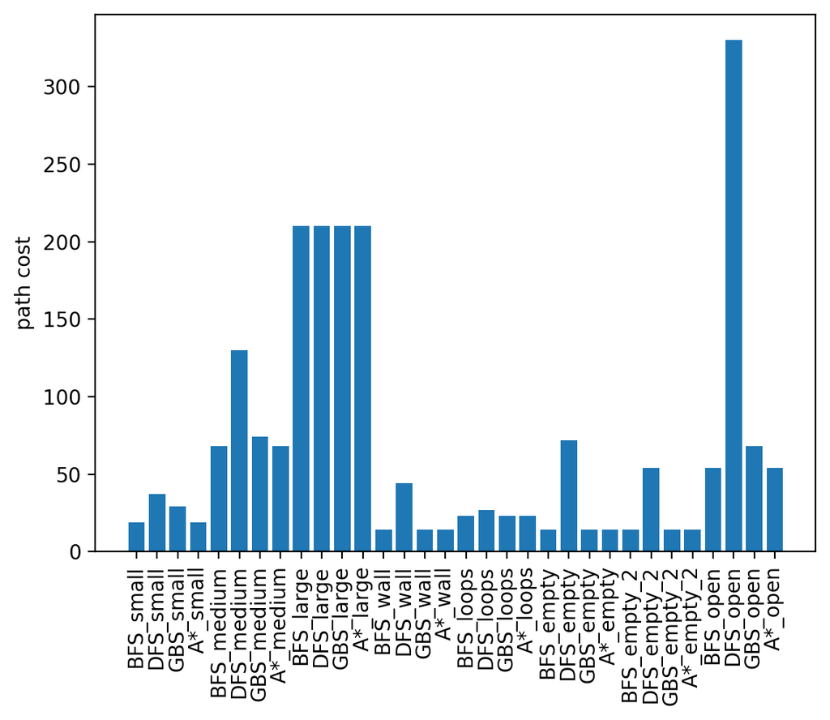

```python
import matplotlib.pyplot as plt
path_costs = list(df_small['Path Cost'])+list(df_medium['Path Cost'])+list(df_large['Path Cost'])+list(
    df_wall['Path Cost'])+ list(df_loops['Path Cost']) + list(df_empty['Path Cost'])+ list(df_empty_2['Path Cost'])+ list(df_open['Path Cost'])

# Create the labels for each bar
labels = ['BFS_small', 'DFS_small', 'GBS_small', 'A*_small',
          'BFS_medium', 'DFS_medium', 'GBS_medium', 'A*_medium',
          'BFS_large', 'DFS_large', 'GBS_large', 'A*_large',
          'BFS_wall', 'DFS_wall', 'GBS_wall', 'A*_wall',
          'BFS_loops', 'DFS_loops', 'GBS_loops', 'A*_loops',
          'BFS_empty', 'DFS_empty', 'GBS_empty', 'A*_empty',
          'BFS_empty_2', 'DFS_empty_2', 'GBS_empty_2', 'A*_empty_2',
          'BFS_open', 'DFS_open', 'GBS_open', 'A*_open']

# Plot the bar chart
plt.bar(labels, path_costs)
plt.ylabel("path cost")
plt.xticks(rotation=90)
plt.show()
```

[figure not shown]

```python
import matplotlib.pyplot as plt
path_costs = list(df_small['# of Nodes Expanded'])+list(df_medium['# of Nodes Expanded'])+list(df_large['# of Nodes Expanded'])+list(
    df_wall['# of Nodes Expanded'])+ list(df_loops['# of Nodes Expanded']) + list(
    df_empty['# of Nodes Expanded'])+ list(df_empty_2['# of Nodes Expanded'])+ list(df_open['# of Nodes Expanded'])

# Create the labels for each bar
labels = ['BFS_small', 'DFS_small', 'GBS_small', 'A*_small',
          'BFS_medium', 'DFS_medium', 'GBS_medium', 'A*_medium',
          'BFS_large', 'DFS_large', 'GBS_large', 'A*_large',
          'BFS_wall', 'DFS_wall', 'GBS_wall', 'A*_wall',
          'BFS_loops', 'DFS_loops', 'GBS_loops', 'A*_loops',
          'BFS_empty', 'DFS_empty', 'GBS_empty', 'A*_empty',
          'BFS_empty_2', 'DFS_empty_2', 'GBS_empty_2', 'A*_empty_2',
          'BFS_open', 'DFS_open', 'GBS_open', 'A*_open']

# Plot the bar chart
plt.bar(labels, path_costs)
plt.ylabel("path cost")
plt.xticks(rotation=90)
plt.show()
```

[figure not shown]

```python
import matplotlib.pyplot as plt
path_costs = list(df_small['Max Tree Depth'])+list(df_medium['Max Tree Depth'])+list(df_large['Max Tree Depth'])+list(
    df_wall['Max Tree Depth'])+ list(df_loops['Max Tree Depth']) + list(
    df_empty['Max Tree Depth'])+ list(df_empty_2['Max Tree Depth'])+ list(df_open['Max Tree Depth'])

# Create the labels for each bar
labels = ['BFS_small', 'DFS_small', 'GBS_small', 'A*_small',
          'BFS_medium', 'DFS_medium', 'GBS_medium', 'A*_medium',
          'BFS_large', 'DFS_large', 'GBS_large', 'A*_large',
          'BFS_wall', 'DFS_wall', 'GBS_wall', 'A*_wall',
          'BFS_loops', 'DFS_loops', 'GBS_loops', 'A*_loops',
          'BFS_empty', 'DFS_empty', 'GBS_empty', 'A*_empty',
          'BFS_empty_2', 'DFS_empty_2', 'GBS_empty_2', 'A*_empty_2',
          'BFS_open', 'DFS_open', 'GBS_open', 'A*_open']

# Plot the bar chart
plt.bar(labels, path_costs)
plt.ylabel("path cost")
plt.xticks(rotation=90)
plt.show()
```

[figure not shown]

```python
import matplotlib.pyplot as plt
path_costs = list(df_small['Max # of Nodes in Memory'])+list(df_medium['Max # of Nodes in Memory'])+list(df_large['Max # of Nodes in Memory'])+list(
    df_wall['Max # of Nodes in Memory'])+ list(df_loops['Max # of Nodes in Memory']) + list(
    df_empty['Max # of Nodes in Memory'])+ list(df_empty_2['Max # of Nodes in Memory'])+ list(df_open['Max # of Nodes in Memory'])

# Create the labels for each bar
labels = ['BFS_small', 'DFS_small', 'GBS_small', 'A*_small',
          'BFS_medium', 'DFS_medium', 'GBS_medium', 'A*_medium',
          'BFS_large', 'DFS_large', 'GBS_large', 'A*_large',
          'BFS_wall', 'DFS_wall', 'GBS_wall', 'A*_wall',
          'BFS_loops', 'DFS_loops', 'GBS_loops', 'A*_loops',
          'BFS_empty', 'DFS_empty', 'GBS_empty', 'A*_empty',
          'BFS_empty_2', 'DFS_empty_2', 'GBS_empty_2', 'A*_empty_2',
          'BFS_open', 'DFS_open', 'GBS_open', 'A*_open']

# Plot the bar chart
plt.bar(labels, path_costs)
plt.ylabel("path cost")
plt.xticks(rotation=90)
plt.show()
```

Discuss the most important lessons you have learned from implementing the different search strategies.

BFS assures finding the shortest path if one exists, but at the cost of high memory utilization, especially in large state spaces.When the search space is large, it can soon become inefficient since it investigates all possible node level by level. DFS is memory efficient as it does not keep the track of visited nodes and clear its history. However, it may miss optimal solutions and can get stuck in infinite loops if there are cycles, making it incomplete unless modified with a depth limit or cycle detection. GBS performs the search using a heuristic, which narrows the search space that is investigated. However, as it does not consider the cost of the path already taken, it may not find the optimal path. A *integrates both the path cost and a heuristic. A* finds the optimal solution (if admissionable) while being more efficient than BFS because it avoids exploring paths that are unlikely to be part of the optimal solution. overall, BFS is well-suited for problems where finding the shortest path is critical, and the state space is not too large. DFS works well in situations where memory is limited, but the solution depth is unknown or the search space is deep. GBS can be useful in situations where a quick solution is needed and optimality is not the primary concern. A* is preferred when both efficiency and optimality are required, and an appropriate heuristic is available.

## Advanced task: IDS and Multiple goals

- **Graduate students** need to complete this task [10 points]
- **Undergraduate students** can attempt this as a bonus task [max +5 bonus points].

### IDS

Implement IDS (iterative deepening search) using your DFS implementation. Test IDS on the mazes above. You may run into some issues with mazes with open spaces. If you cannot resolve the issus, then report and discuss what causes the problems.

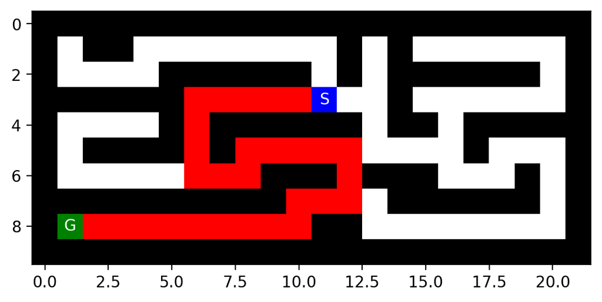

```python
class Node:
    def __init__(self, pos, parent=None, action=None, cost=0):
        self.pos = tuple(pos)    # the state; positions are (row, col)
        self.parent = parent     # reference to parent node. None means root node.
        self.action = action     # action used in the transition function (root node has None)
        self.cost = cost         # for uniform cost this is the depth

    def __str__(self):
        return f"Node - pos = {self.pos}; action = {self.action}; cost = {self.cost}"

    def get_path_from_root(self):
        """Returns nodes on the path from the root to the current node."""
        node = self
        path = [node]
        while node.parent is not None:
            node = node.parent
            path.append(node)
        path.reverse()
        return path


ACTIONS = [(-1, 0, 'North'), (1, 0, 'South'), (0, -1, 'West'), (0, 1, 'East')]

def mark_maze(maze, pos, symbol):
    """Marks the maze at a given position with a symbol."""
    maze[pos[0]][pos[1]] = symbol


def depth_limited_search(maze, node, goal, limit, visited):
    """Performs a depth-limited search."""
    if node.pos == goal:  # Check if current node is the goal
        return node.get_path_from_root()

    if limit == 0:  # If the depth limit is reached, stop expanding
        return None

    visited.add(node.pos)  # Add the current node to visited nodes

    for dx, dy, action in ACTIONS:
        next_pos = (node.pos[0] + dx, node.pos[1] + dy)  # Calculate next position
        if mh.look(maze, next_pos) != 'X' and next_pos not in visited:  # Check for valid move
            child = Node(next_pos, node, action, node.cost + 1)  # Create child node
            result = depth_limited_search(maze, child, goal, limit - 1, visited)  # Recursive call with depth limit reduced
            if result is not None:  # If a solution is found, return it
                return result

    return None


def iterative_deepening_search(maze, start, goal):
    """Performs an Iterative Deepening Search (IDS)."""
    depth = 0  # Start with a depth limit of 0 and increase iteratively
    while True:
        visited = set()  # Reset visited nodes for each new depth limit
        initial_node = Node(pos=start)
        result = depth_limited_search(maze, initial_node, goal, depth, visited)
        if result is not None:  # If a solution is found, return the path
            return result
        depth += 1  # Increment the depth limit for the next iteration


# Test the IDS on a maze
with open("small_maze.txt", "r") as f:
    maze_str = f.read()

maze = mh.parse_maze(maze_str)
start = mh.find_pos(maze, what="S")
goal = mh.find_pos(maze, what="G")

print('start point is', start, 'goal point is', goal)
solution_path = iterative_deepening_search(maze, start, goal)

# Mark the solution path in the maze
if solution_path:
    for path_node in solution_path:
        if mh.look(maze, path_node.pos) != 'G' and mh.look(maze, path_node.pos) != 'S':
            mark_maze(maze, path_node.pos, 'P')
        clear_output(wait=True)
        mh.show_maze(maze)
```

### medium maze

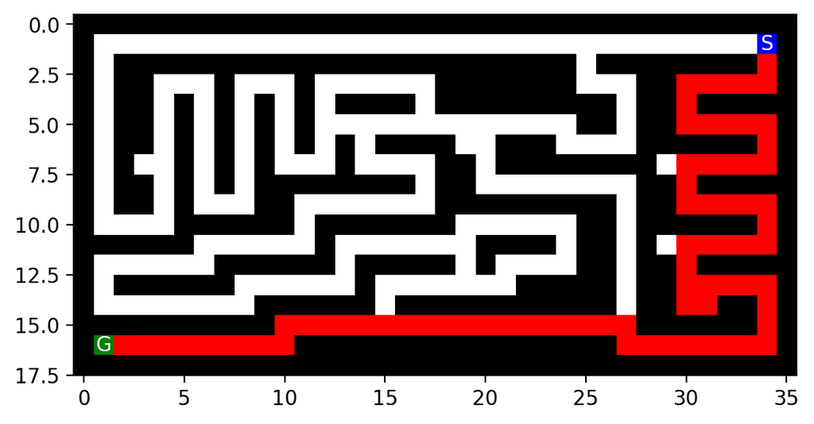

```python
class Node:
    def __init__(self, pos, parent=None, action=None, cost=0):
        self.pos = tuple(pos)    # the state; positions are (row, col)
        self.parent = parent     # reference to parent node. None means root node.
        self.action = action     # action used in the transition function (root node has None)
        self.cost = cost         # for uniform cost this is the depth

    def __str__(self):
        return f"Node - pos = {self.pos}; action = {self.action}; cost = {self.cost}"

    def get_path_from_root(self):
        """Returns nodes on the path from the root to the current node."""
        node = self
        path = [node]
        while node.parent is not None:
            node = node.parent
            path.append(node)
        path.reverse()
        return path


ACTIONS = [(-1, 0, 'North'), (1, 0, 'South'), (0, -1, 'West'), (0, 1, 'East')]

def mark_maze(maze, pos, symbol):
    """Marks the maze at a given position with a symbol."""
    maze[pos[0]][pos[1]] = symbol


def depth_limited_search(maze, node, goal, limit, visited):
    """Performs a depth-limited search."""
    if node.pos == goal:  # Check if current node is the goal
        return node.get_path_from_root()

    if limit == 0:  # If the depth limit is reached, stop expanding
        return None

    visited.add(node.pos)  # Add the current node to visited nodes

    for dx, dy, action in ACTIONS:
        next_pos = (node.pos[0] + dx, node.pos[1] + dy)  # Calculate next position
        if mh.look(maze, next_pos) != 'X' and next_pos not in visited:  # Check for valid move
            child = Node(next_pos, node, action, node.cost + 1)  # Create child node
            result = depth_limited_search(maze, child, goal, limit - 1, visited)  # Recursive call with depth limit reduced
            if result is not None:  # If a solution is found, return it
                return result

    return None


def iterative_deepening_search(maze, start, goal):
    """Performs an Iterative Deepening Search (IDS)."""
    depth = 0  # Start with a depth limit of 0 and increase iteratively
    while True:
        visited = set()  # Reset visited nodes for each new depth limit
        initial_node = Node(pos=start)
        result = depth_limited_search(maze, initial_node, goal, depth, visited)
        if result is not None:  # If a solution is found, return the path
            return result
        depth += 1  # Increment the depth limit for the next iteration


# Test the IDS on a maze
with open("medium_maze.txt", "r") as f:
    maze_str = f.read()

maze = mh.parse_maze(maze_str)
start = mh.find_pos(maze, what="S")
goal = mh.find_pos(maze, what="G")

print('start point is', start, 'goal point is', goal)
solution_path = iterative_deepening_search(maze, start, goal)

# Mark the solution path in the maze
if solution_path:
    for path_node in solution_path:
        if mh.look(maze, path_node.pos) != 'G' and mh.look(maze, path_node.pos) != 'S':
            mark_maze(maze, path_node.pos, 'P')
        clear_output(wait=True)
        mh.show_maze(maze)
```

### large maze

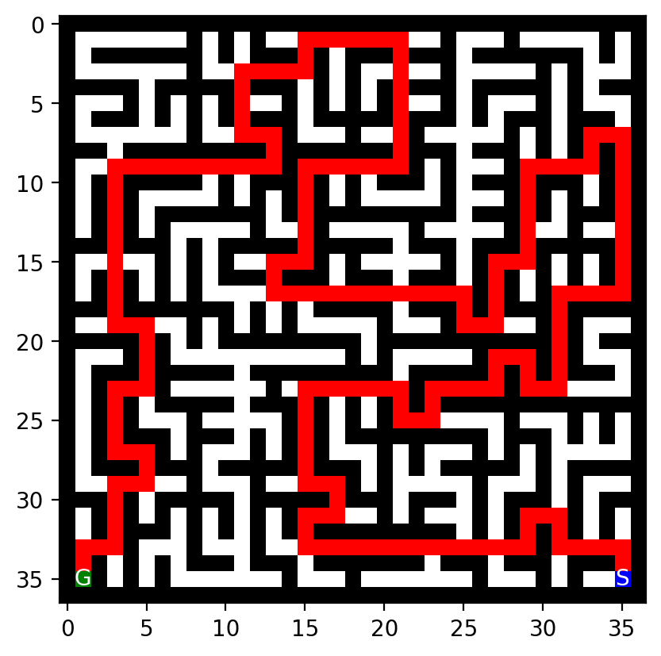

```python
class Node:
    def __init__(self, pos, parent=None, action=None, cost=0):
        self.pos = tuple(pos)    # the state; positions are (row, col)
        self.parent = parent     # reference to parent node. None means root node.
        self.action = action     # action used in the transition function (root node has None)
        self.cost = cost         # for uniform cost this is the depth

    def __str__(self):
        return f"Node - pos = {self.pos}; action = {self.action}; cost = {self.cost}"

    def get_path_from_root(self):
        """Returns nodes on the path from the root to the current node."""
        node = self
        path = [node]
        while node.parent is not None:
            node = node.parent
            path.append(node)
        path.reverse()
        return path


ACTIONS = [(-1, 0, 'North'), (1, 0, 'South'), (0, -1, 'West'), (0, 1, 'East')]

def mark_maze(maze, pos, symbol):
    """Marks the maze at a given position with a symbol."""
    maze[pos[0]][pos[1]] = symbol


def depth_limited_search(maze, node, goal, limit, visited):
    """Performs a depth-limited search."""
    if node.pos == goal:  # Check if current node is the goal
        return node.get_path_from_root()

    if limit == 0:  # If the depth limit is reached, stop expanding
        return None

    visited.add(node.pos)  # Add the current node to visited nodes

    for dx, dy, action in ACTIONS:
        next_pos = (node.pos[0] + dx, node.pos[1] + dy)  # Calculate next position
        if mh.look(maze, next_pos) != 'X' and next_pos not in visited:  # Check for valid move
            child = Node(next_pos, node, action, node.cost + 1)  # Create child node
            result = depth_limited_search(maze, child, goal, limit - 1, visited)  # Recursive call with depth limit reduced
            if result is not None:  # If a solution is found, return it
                return result

    return None


def iterative_deepening_search(maze, start, goal):
    """Performs an Iterative Deepening Search (IDS)."""
    depth = 0  # Start with a depth limit of 0 and increase iteratively
    while True:
        visited = set()  # Reset visited nodes for each new depth limit
        initial_node = Node(pos=start)
        result = depth_limited_search(maze, initial_node, goal, depth, visited)
        if result is not None:  # If a solution is found, return the path
            return result
        depth += 1  # Increment the depth limit for the next iteration


# Test the IDS on a maze
with open("large_maze.txt", "r") as f:
    maze_str = f.read()

maze = mh.parse_maze(maze_str)
start = mh.find_pos(maze, what="S")
goal = mh.find_pos(maze, what="G")

print('start point is', start, 'goal point is', goal)
solution_path = iterative_deepening_search(maze, start, goal)

# Mark the solution path in the maze
if solution_path:
    for path_node in solution_path:
        if mh.look(maze, path_node.pos) != 'G' and mh.look(maze, path_node.pos) != 'S':
            mark_maze(maze, path_node.pos, 'P')
        clear_output(wait=True)
        mh.show_maze(maze)
```

### open Maze

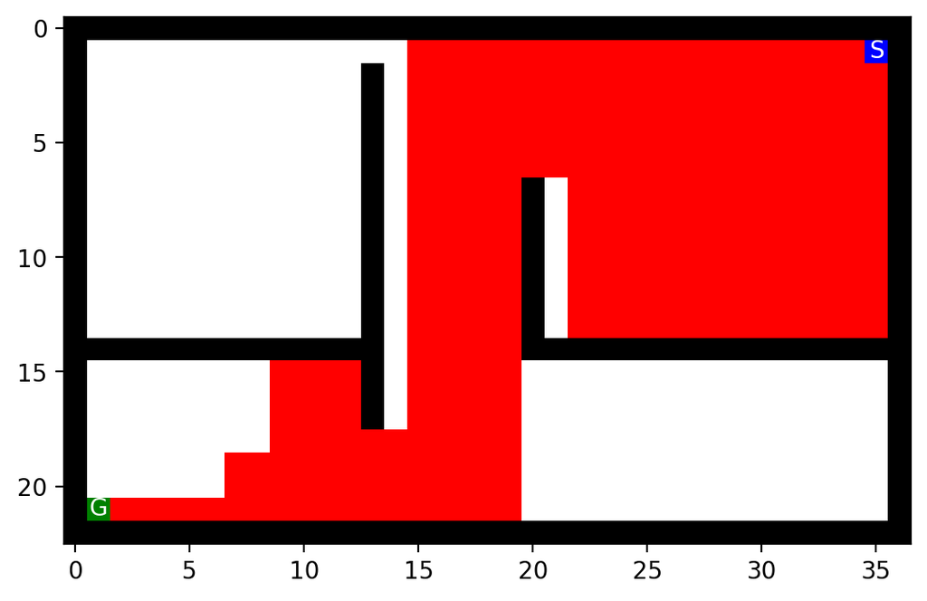

```python
class Node:
    def __init__(self, pos, parent=None, action=None, cost=0):
        self.pos = tuple(pos)    # the state; positions are (row, col)
        self.parent = parent     # reference to parent node. None means root node.
        self.action = action     # action used in the transition function (root node has None)
        self.cost = cost         # for uniform cost this is the depth

    def __str__(self):
        return f"Node - pos = {self.pos}; action = {self.action}; cost = {self.cost}"

    def get_path_from_root(self):
        """Returns nodes on the path from the root to the current node."""
        node = self
        path = [node]
        while node.parent is not None:
            node = node.parent
            path.append(node)
        path.reverse()
        return path


ACTIONS = [(-1, 0, 'North'), (1, 0, 'South'), (0, -1, 'West'), (0, 1, 'East')]

def mark_maze(maze, pos, symbol):
    """Marks the maze at a given position with a symbol."""
    maze[pos[0]][pos[1]] = symbol


def depth_limited_search(maze, node, goal, limit, visited):
    """Performs a depth-limited search."""
    if node.pos == goal:  # Check if current node is the goal
        return node.get_path_from_root()

    if limit == 0:  # If the depth limit is reached, stop expanding
        return None

    visited.add(node.pos)  # Add the current node to visited nodes

    for dx, dy, action in ACTIONS:
        next_pos = (node.pos[0] + dx, node.pos[1] + dy)  # Calculate next position
        if mh.look(maze, next_pos) != 'X' and next_pos not in visited:  # Check for valid move
            child = Node(next_pos, node, action, node.cost + 1)  # Create child node
            result = depth_limited_search(maze, child, goal, limit - 1, visited)  # Recursive call with depth limit reduced
            if result is not None:  # If a solution is found, return it
                return result

    return None


def iterative_deepening_search(maze, start, goal):
    """Performs an Iterative Deepening Search (IDS)."""
    depth = 0  # Start with a depth limit of 0 and increase iteratively
    while True:
        visited = set()  # Reset visited nodes for each new depth limit
        initial_node = Node(pos=start)
        result = depth_limited_search(maze, initial_node, goal, depth, visited)
        if result is not None:  # If a solution is found, return the path
            return result
        depth += 1  # Increment the depth limit for the next iteration


# Test the IDS on a maze
with open("open_maze.txt", "r") as f:
    maze_str = f.read()

maze = mh.parse_maze(maze_str)
start = mh.find_pos(maze, what="S")
goal = mh.find_pos(maze, what="G")

print('start point is', start, 'goal point is', goal)
solution_path = iterative_deepening_search(maze, start, goal)

# Mark the solution path in the maze
if solution_path:
    for path_node in solution_path:
        if mh.look(maze, path_node.pos) != 'G' and mh.look(maze, path_node.pos) != 'S':
            mark_maze(maze, path_node.pos, 'P')
        clear_output(wait=True)
        mh.show_maze(maze)
```

### Wall maze

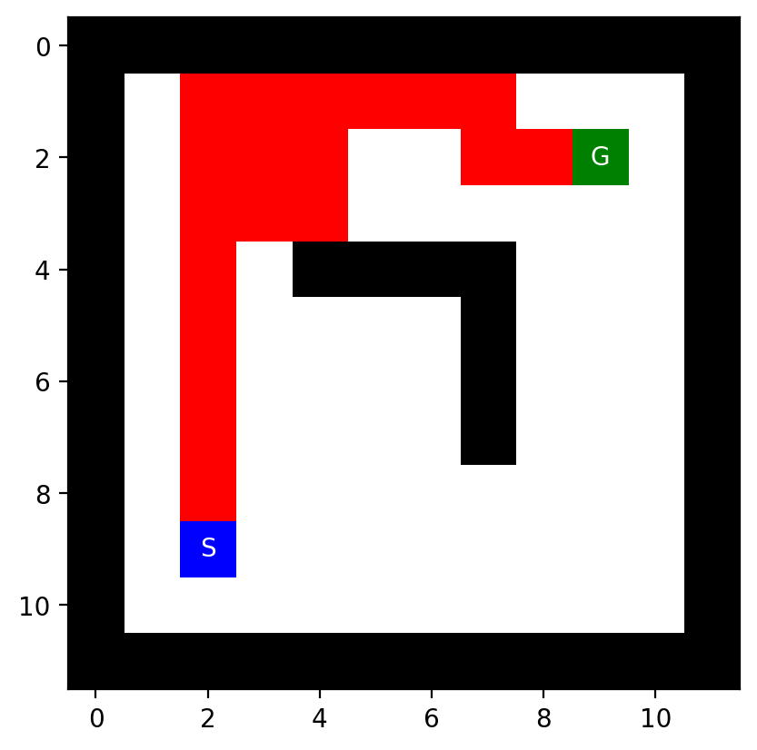

```python
class Node:
    def __init__(self, pos, parent=None, action=None, cost=0):
        self.pos = tuple(pos)    # the state; positions are (row, col)
        self.parent = parent     # reference to parent node. None means root node.
        self.action = action     # action used in the transition function (root node has None)
        self.cost = cost         # for uniform cost this is the depth

    def __str__(self):
        return f"Node - pos = {self.pos}; action = {self.action}; cost = {self.cost}"

    def get_path_from_root(self):
        """Returns nodes on the path from the root to the current node."""
        node = self
        path = [node]
        while node.parent is not None:
            node = node.parent
            path.append(node)
        path.reverse()
        return path


ACTIONS = [(-1, 0, 'North'), (1, 0, 'South'), (0, -1, 'West'), (0, 1, 'East')]

def mark_maze(maze, pos, symbol):
    """Marks the maze at a given position with a symbol."""
    maze[pos[0]][pos[1]] = symbol


def depth_limited_search(maze, node, goal, limit, visited):
    """Performs a depth-limited search."""
    if node.pos == goal:  # Check if current node is the goal
        return node.get_path_from_root()

    if limit == 0:  # If the depth limit is reached, stop expanding
        return None

    visited.add(node.pos)  # Add the current node to visited nodes

    for dx, dy, action in ACTIONS:
        next_pos = (node.pos[0] + dx, node.pos[1] + dy)  # Calculate next position
        if mh.look(maze, next_pos) != 'X' and next_pos not in visited:  # Check for valid move
            child = Node(next_pos, node, action, node.cost + 1)  # Create child node
            result = depth_limited_search(maze, child, goal, limit - 1, visited)  # Recursive call with depth limit reduced
            if result is not None:  # If a solution is found, return it
                return result

    return None


def iterative_deepening_search(maze, start, goal):
    """Performs an Iterative Deepening Search (IDS)."""
    depth = 0  # Start with a depth limit of 0 and increase iteratively
    while True:
        visited = set()  # Reset visited nodes for each new depth limit
        initial_node = Node(pos=start)
        result = depth_limited_search(maze, initial_node, goal, depth, visited)
        if result is not None:  # If a solution is found, return the path
            return result
        depth += 1  # Increment the depth limit for the next iteration


# Test the IDS on a maze
with open("wall_maze.txt", "r") as f:
    maze_str = f.read()

maze = mh.parse_maze(maze_str)
start = mh.find_pos(maze, what="S")
goal = mh.find_pos(maze, what="G")

print('start point is', start, 'goal point is', goal)
solution_path = iterative_deepening_search(maze, start, goal)

# Mark the solution path in the maze
if solution_path:
    for path_node in solution_path:
        if mh.look(maze, path_node.pos) != 'G' and mh.look(maze, path_node.pos) != 'S':
            mark_maze(maze, path_node.pos, 'P')
        clear_output(wait=True)
        mh.show_maze(maze)
```

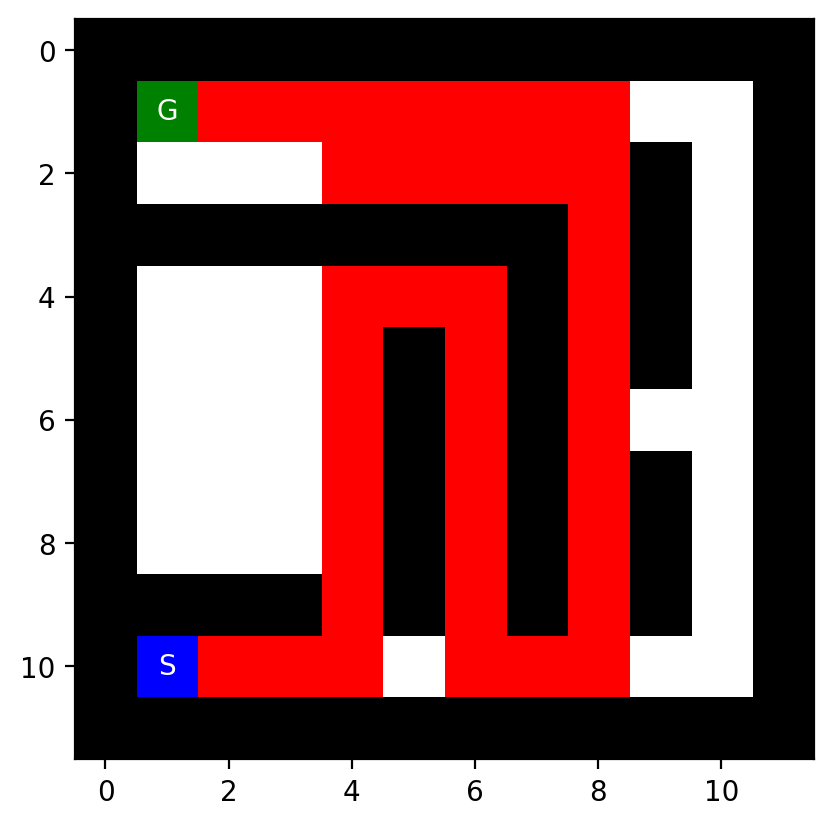

```python
class Node:
    def __init__(self, pos, parent=None, action=None, cost=0):
        self.pos = tuple(pos)    # the state; positions are (row, col)
        self.parent = parent     # reference to parent node. None means root node.
        self.action = action     # action used in the transition function (root node has None)
        self.cost = cost         # for uniform cost this is the depth

    def __str__(self):
        return f"Node - pos = {self.pos}; action = {self.action}; cost = {self.cost}"

    def get_path_from_root(self):
        """Returns nodes on the path from the root to the current node."""
        node = self
        path = [node]
        while node.parent is not None:
            node = node.parent
            path.append(node)
        path.reverse()
        return path


ACTIONS = [(-1, 0, 'North'), (1, 0, 'South'), (0, -1, 'West'), (0, 1, 'East')]

def mark_maze(maze, pos, symbol):
    """Marks the maze at a given position with a symbol."""
    maze[pos[0]][pos[1]] = symbol


def depth_limited_search(maze, node, goal, limit, visited):
    """Performs a depth-limited search."""
    if node.pos == goal:  # Check if current node is the goal
        return node.get_path_from_root()

    if limit == 0:  # If the depth limit is reached, stop expanding
        return None

    visited.add(node.pos)  # Add the current node to visited nodes

    for dx, dy, action in ACTIONS:
        next_pos = (node.pos[0] + dx, node.pos[1] + dy)  # Calculate next position
        if mh.look(maze, next_pos) != 'X' and next_pos not in visited:  # Check for valid move
            child = Node(next_pos, node, action, node.cost + 1)  # Create child node
            result = depth_limited_search(maze, child, goal, limit - 1, visited)  # Recursive call with depth limit reduced
            if result is not None:  # If a solution is found, return it
                return result

    return None


def iterative_deepening_search(maze, start, goal):
    """Performs an Iterative Deepening Search (IDS)."""
    depth = 0  # Start with a depth limit of 0 and increase iteratively
    while True:
        visited = set()  # Reset visited nodes for each new depth limit
        initial_node = Node(pos=start)
        result = depth_limited_search(maze, initial_node, goal, depth, visited)
        if result is not None:  # If a solution is found, return the path
            return result
        depth += 1  # Increment the depth limit for the next iteration


# Test the IDS on a maze
with open("loops_maze.txt", "r") as f:
    maze_str = f.read()

maze = mh.parse_maze(maze_str)
start = mh.find_pos(maze, what="S")
goal = mh.find_pos(maze, what="G")

print('start point is', start, 'goal point is', goal)
solution_path = iterative_deepening_search(maze, start, goal)

# Mark the solution path in the maze
if solution_path:
    for path_node in solution_path:
        if mh.look(maze, path_node.pos) != 'G' and mh.look(maze, path_node.pos) != 'S':
            mark_maze(maze, path_node.pos, 'P')
        clear_output(wait=True)
        mh.show_maze(maze)
```

### empty maze

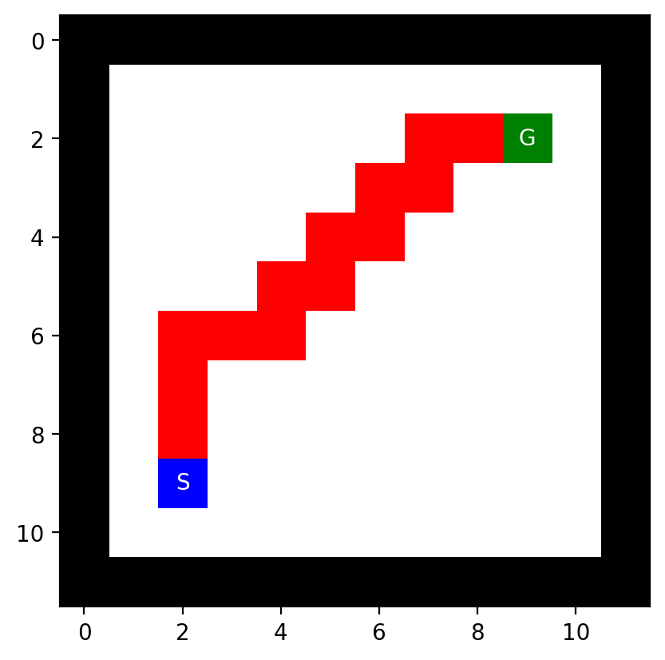

```python
class Node:
    def __init__(self, pos, parent=None, action=None, cost=0):
        self.pos = tuple(pos)    # the state; positions are (row, col)
        self.parent = parent     # reference to parent node. None means root node.
        self.action = action     # action used in the transition function (root node has None)
        self.cost = cost         # for uniform cost this is the depth

    def __str__(self):
        return f"Node - pos = {self.pos}; action = {self.action}; cost = {self.cost}"

    def get_path_from_root(self):
        """Returns nodes on the path from the root to the current node."""
        node = self
        path = [node]
        while node.parent is not None:
            node = node.parent
            path.append(node)
        path.reverse()
        return path


ACTIONS = [(-1, 0, 'North'), (1, 0, 'South'), (0, -1, 'West'), (0, 1, 'East')]

def mark_maze(maze, pos, symbol):
    """Marks the maze at a given position with a symbol."""
    maze[pos[0]][pos[1]] = symbol


def depth_limited_search(maze, node, goal, limit, visited):
    """Performs a depth-limited search."""
    if node.pos == goal:  # Check if current node is the goal
        return node.get_path_from_root()

    if limit == 0:  # If the depth limit is reached, stop expanding
        return None

    visited.add(node.pos)  # Add the current node to visited nodes

    for dx, dy, action in ACTIONS:
        next_pos = (node.pos[0] + dx, node.pos[1] + dy)  # Calculate next position
        if mh.look(maze, next_pos) != 'X' and next_pos not in visited:  # Check for valid move
            child = Node(next_pos, node, action, node.cost + 1)  # Create child node
            result = depth_limited_search(maze, child, goal, limit - 1, visited)  # Recursive call with depth limit reduced
            if result is not None:  # If a solution is found, return it
                return result

    return None


def iterative_deepening_search(maze, start, goal):
    """Performs an Iterative Deepening Search (IDS)."""
    depth = 0  # Start with a depth limit of 0 and increase iteratively
    while True:
        visited = set()  # Reset visited nodes for each new depth limit
        initial_node = Node(pos=start)
        result = depth_limited_search(maze, initial_node, goal, depth, visited)
        if result is not None:  # If a solution is found, return the path
            return result
        depth += 1  # Increment the depth limit for the next iteration


# Test the IDS on a maze
with open("empty_maze.txt", "r") as f:
    maze_str = f.read()

maze = mh.parse_maze(maze_str)
start = mh.find_pos(maze, what="S")
goal = mh.find_pos(maze, what="G")

print('start point is', start, 'goal point is', goal)
solution_path = iterative_deepening_search(maze, start, goal)

# Mark the solution path in the maze
if solution_path:
    for path_node in solution_path:
        if mh.look(maze, path_node.pos) != 'G' and mh.look(maze, path_node.pos) != 'S':
            mark_maze(maze, path_node.pos, 'P')
        clear_output(wait=True)
        mh.show_maze(maze)
```

### empty_2_maze

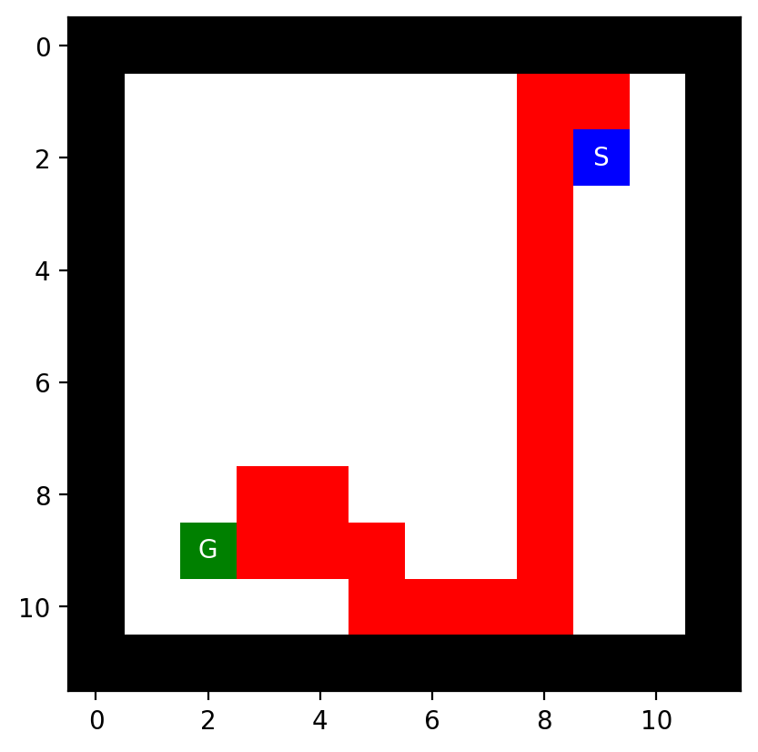

```python
class Node:
    def __init__(self, pos, parent=None, action=None, cost=0):
        self.pos = tuple(pos)    # the state; positions are (row, col)
        self.parent = parent     # reference to parent node. None means root node.
        self.action = action     # action used in the transition function (root node has None)
        self.cost = cost         # for uniform cost this is the depth

    def __str__(self):
        return f"Node - pos = {self.pos}; action = {self.action}; cost = {self.cost}"

    def get_path_from_root(self):
        """Returns nodes on the path from the root to the current node."""
        node = self
        path = [node]
        while node.parent is not None:
            node = node.parent
            path.append(node)
        path.reverse()
        return path


ACTIONS = [(-1, 0, 'North'), (1, 0, 'South'), (0, -1, 'West'), (0, 1, 'East')]

def mark_maze(maze, pos, symbol):
    """Marks the maze at a given position with a symbol."""
    maze[pos[0]][pos[1]] = symbol


def depth_limited_search(maze, node, goal, limit, visited):
    """Performs a depth-limited search."""
    if node.pos == goal:  # Check if current node is the goal
        return node.get_path_from_root()

    if limit == 0:  # If the depth limit is reached, stop expanding
        return None

    visited.add(node.pos)  # Add the current node to visited nodes

    for dx, dy, action in ACTIONS:
        next_pos = (node.pos[0] + dx, node.pos[1] + dy)  # Calculate next position
        if mh.look(maze, next_pos) != 'X' and next_pos not in visited:  # Check for valid move
            child = Node(next_pos, node, action, node.cost + 1)  # Create child node
            result = depth_limited_search(maze, child, goal, limit - 1, visited)  # Recursive call with depth limit reduced
            if result is not None:  # If a solution is found, return it
                return result

    return None


def iterative_deepening_search(maze, start, goal):
    """Performs an Iterative Deepening Search (IDS)."""
    depth = 0  # Start with a depth limit of 0 and increase iteratively
    while True:
        visited = set()  # Reset visited nodes for each new depth limit
        initial_node = Node(pos=start)
        result = depth_limited_search(maze, initial_node, goal, depth, visited)
        if result is not None:  # If a solution is found, return the path
            return result
        depth += 1  # Increment the depth limit for the next iteration


# Test the IDS on a maze
with open("empty_2_maze.txt", "r") as f:
    maze_str = f.read()

maze = mh.parse_maze(maze_str)
start = mh.find_pos(maze, what="S")
goal = mh.find_pos(maze, what="G")

print('start point is', start, 'goal point is', goal)
solution_path = iterative_deepening_search(maze, start, goal)

# Mark the solution path in the maze
if solution_path:
    for path_node in solution_path:
        if mh.look(maze, path_node.pos) != 'G' and mh.look(maze, path_node.pos) != 'S':
            mark_maze(maze, path_node.pos, 'P')
        clear_output(wait=True)
        mh.show_maze(maze)
```

### Multiple Goals

Create a few mazes with multiple goals by adding one or two more goals to the medium size maze. The agent is done when it finds one of the goals. Solve the maze with your implementations for DFS, BFS, and IDS. Run experiments to show which implementations find the optimal solution and which do not. Discuss why that is the case.

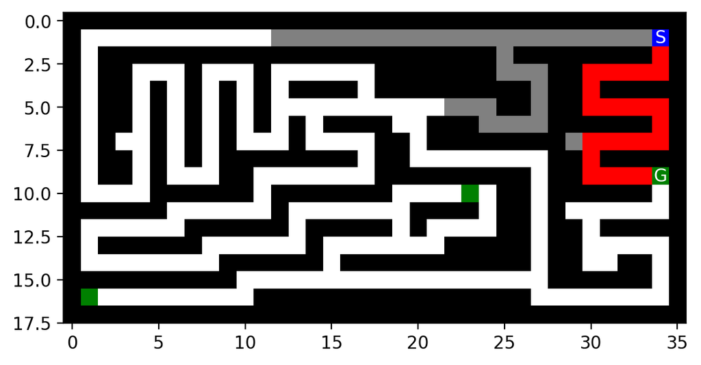

|  | Algorithm | Path Cost | Nodes Expanded | Max Tree Depth | Max Frontier Size | max memory usage |
| --- | --- | --- | --- | --- | --- | --- |
| 0 | BFS | 24 | 60 | 24 | 4 | 65 |

```python
class Node:
    def __init__(self, pos, parent=None, action=None, cost=0):
        self.pos = tuple(pos)    # the state; positions are (row,col)
        self.parent = parent     # reference to parent node. None means root node.
        self.action = action     # action used in the transition function (root node has None)
        self.cost = cost         # for uniform cost this is the depth. It is also g(n) for A* search

    def __str__(self):
        return f"Node - pos = {self.pos}; action = {self.action}; cost = {self.cost}"

    def get_path_from_root(self):
        """returns nodes on the path from the root to the current node."""
        node = self
        path = [node]

        while not node.parent is None:
            node = node.parent
            path.append(node)


        path.reverse()

        return(path)
ACTIONS = [(-1, 0, 'North'), (1, 0, 'South'), (0, -1, 'West'), (0, 1, 'East')]
def mark_maze(maze, pos, symbol):
    """Marks the maze at a given position with a symbol."""
    maze[pos[0]][pos[1]] = symbol

def BFS(maze, start, goal):
    # Initialize the initial node and check if it's the goal
    initial_node = Node(pos=start)
    if start == goal:  # Check if the initial state is the goal
        return initial_node.get_path_from_root(), 0, 0, 0, 0

    # Initialize the frontier (FIFO queue) and reached set
    frontier = [initial_node]  # Frontier initialized with the initial node
    reached = set()  # Reached set to track visited nodes
    reached.add(start)

    # Metrics tracking
    nodes_expanded = 0  # Total nodes expanded
    max_tree_depth = 0  # Maximum depth of the tree
    max_frontier_size = 1  # Maximum size of the frontier (starts with 1, the initial node)
    max_memory_usage = 1  # Maximum number of nodes in memory (frontier + reached)
    # Loop until we either find the goal or exhaust the frontier
    while frontier:
        node = frontier.pop(0)  # Expand the node (FIFO behavior)
        nodes_expanded += 1  # Increment the expanded nodes counter

        # Mark the node as visited (for visualization purposes)
        if mh.look(maze, node.pos) != 'S':
            mark_maze(maze, node.pos, '.')

        # Loop through possible actions (North, South, West, East)
        for dx, dy, action in ACTIONS:
            next_pos = (node.pos[0] + dx, node.pos[1] + dy)  # Next position

            # Check if next position is valid (not a wall or already reached)
            if mh.look(maze, next_pos) != 'X' and next_pos not in reached:
                reached.add(next_pos)  # Add the next position to the reached set

                # Create child node
                child = Node(next_pos, node, action, node.cost + 1)  # Child node with updated cost (depth)

                # Add child to the frontier
                frontier.append(child)

                # Track maximum tree depth
                max_tree_depth = max(max_tree_depth, child.cost)

                # Track maximum frontier size
                max_frontier_size = max(max_frontier_size, len(frontier))

                # If the goal is reached, return the solution path and metrics
                if mh.look(maze, next_pos) == 'G':
                    solution_path = child.get_path_from_root()
                    path_cost = len(solution_path) - 1
                    for path_node in solution_path:
                        if mh.look(maze, path_node.pos) != 'G' and mh.look(maze, path_node.pos) != 'S':
                            mark_maze(maze, path_node.pos, 'P')
                            clear_output(wait=True)
                            mh.show_maze(maze)

                    return (solution_path, path_cost, nodes_expanded, max_tree_depth, max_frontier_size,max_memory_usage)

        max_memory_usage = max(max_memory_usage, len(frontier) + len(reached))
        clear_output(wait=True)
        mh.show_maze(maze)

    # If no solution is found, return None with 0s for all metrics
    return None, 0, nodes_expanded, max_tree_depth, max_frontier_size

with open("medium_maze_2.txt", "r") as f:
    maze_str = f.read()
maze = mh.parse_maze(maze_str)
start= mh.find_pos(maze, what = "S")
goal= mh.find_pos(maze, what = "G")
print('start point is',start,'goal point is',goal)
[solution_path,BFS_medium_path_cost,BFS_medium_nodes_expanded,BFS_medium_max_tree_depth, BFS_medium_max_frontier_size,BFS_medium_memory_usage] = BFS(maze, start, goal)
data = {
    'Algorithm': ['BFS'],
    'Path Cost': [BFS_medium_path_cost],
    'Nodes Expanded': [BFS_medium_nodes_expanded],
    'Max Tree Depth': [BFS_medium_max_tree_depth],
    'Max Frontier Size': [BFS_medium_max_frontier_size],
    'max memory usage':[BFS_medium_memory_usage]
}

# Create a DataFrame
df = pd.DataFrame(data)
df
```

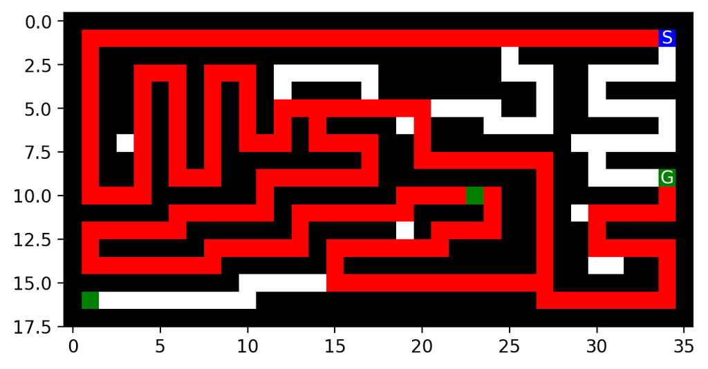

|  | Algorithm | Path Cost | Nodes Expanded | Max Tree Depth | Max Frontier Size | max memory usage |
| --- | --- | --- | --- | --- | --- | --- |
| 0 | DFS | 232 | 410 | 284 | 17 | 264 |

```python
def DFS(maze, start, goal):
    #  Initialize the initial node and check if it's the goal
    initial_node = Node(pos=start)
    if start == goal:  # Check if the initial state is the goal
        return initial_node.get_path_from_root()

    #  Initialize the frontier (FIFO queue) and reached set
    frontier = [initial_node]  # Frontier initialized with the initial node
    reached = set()  # Reached set to track visited nodes
    visited = []  # List to track visited nodes in order
    branch = []   # List to track branching points
    nodes_expanded = 0
    max_tree_depth = 0
    max_frontier_size = 1  # Maximum size of the frontier (starts with 1, the initial node)
    max_memory_usage = 1  # Maximum number of nodes in memory (frontier + reached)
    while frontier:
        node = frontier.pop(-1)  # DFS uses LIFO, so we pop from the end (stack behavior)
        nodes_expanded += 1
        node1 = [(node.pos[0] - 1, node.pos[1]), (node.pos[0] + 1, node.pos[1]),
                 (node.pos[0], node.pos[1] - 1), (node.pos[0], node.pos[1] + 1)]

        # Remove start and goal positions from neighbor list if present
        if mh.find_pos(maze, what="S") in node1:
            node1.pop(node1.index(mh.find_pos(maze, what="S")))
        if mh.find_pos(maze, what="G") in node1:
            node1.pop(node1.index(mh.find_pos(maze, what="G")))

        # Pruning branches if necessary
        while len(visited) > 2 and (visited[-1] not in node1):
            branch.pop(-1)
            last_branch_item = branch[-1]
            if last_branch_item in visited:
                index = visited.index(last_branch_item)
                visited1 = visited[:index + 1]
            for v in visited:
                if v not in visited1 and mh.look(maze, v) != 'G' and mh.look(maze, v) != 'S':
                    mark_maze(maze, v, ' ')
            visited = visited1

        visited.append(node.pos)

        # Mark the current position in the maze if it's not the start or goal
        if mh.look(maze, node.pos) != 'G' and mh.look(maze, node.pos) != 'S':
            mark_maze(maze, node.pos, '.')

        reached.add(node.pos)
        br = 0

        # **Addition**: Check if any neighbor of the current node is the goal
        for dx, dy, action in ACTIONS:
            next_pos = (node.pos[0] + dx, node.pos[1] + dy)  # Calculate next position
            if next_pos == goal:  # Early exit if the next position is the goal
                child = Node(next_pos, node, action, node.cost + 1)
                solution_path = child.get_path_from_root()
                path_cost = len(solution_path) - 1
                # Mark the solution path in the maze
                for path_node in solution_path:
                    if mh.look(maze, path_node.pos) != 'G' and mh.look(maze, path_node.pos) != 'S':
                        mark_maze(maze, path_node.pos, 'P')
                    clear_output(wait=True)
                    mh.show_maze(maze)
                return solution_path, path_cost, nodes_expanded, max_tree_depth, max_frontier_size,max_memory_usage

        # **Continuation of your code**: Expand the search by adding child nodes
        for dx, dy, action in ACTIONS:
            next_pos = (node.pos[0] + dx, node.pos[1] + dy)  # Next position

            if mh.look(maze, next_pos) != 'X' and next_pos not in visited:  # Valid position
                br += 1
                child = Node(next_pos, node, action, node.cost + 1)
                frontier.append(child)  # Add child to frontier
                max_tree_depth = max(max_tree_depth, child.cost)
                max_frontier_size = max(max_frontier_size, len(frontier))
                if br >= 2:
                    branch.append(node.pos)

                if mh.look(maze, node.pos) == 'G' and len(reached) >= 15:
                    last_branch_item = branch[-1]
                    if last_branch_item in visited:
                        index = visited.index(last_branch_item)
                        visited1 = visited[:index + 1]
                    for v in visited:
                        if v not in visited1 and mh.look(maze, v) != 'G' and mh.look(maze, v) != 'S':
                            mark_maze(maze, v, ' ')
                    visited = visited1
                    continue

        if br == 0 and node.pos in visited:
            last_branch_item = branch[-1]
            if last_branch_item in visited:
                index = visited.index(last_branch_item)
                visited1 = visited[:index + 1]
            for v in visited:
                if v not in visited1 and mh.look(maze, v) != 'G' and mh.look(maze, v) != 'S':
                    mark_maze(maze, v, ' ')
            visited = visited1
            continue

        max_memory_usage = max(max_memory_usage, len(frontier) + len(reached))
        clear_output(wait=True)
        mh.show_maze(maze)
with open("medium_maze_2.txt", "r") as f:
    maze_str = f.read()
maze = mh.parse_maze(maze_str)
start= mh.find_pos(maze, what = "S")
goal= mh.find_pos(maze, what = "G")
print('start point is',start,'goal point is',goal)
[solution_path,DFS_small_path_cost,DFS_small_nodes_expanded,DFS_small_max_tree_depth, DFS_small_max_frontier_size,DFS_small_memory_usage] = DFS(maze, start, goal)
data = {
    'Algorithm': ['DFS'],
    'Path Cost': [DFS_small_path_cost],
    'Nodes Expanded': [DFS_small_nodes_expanded],
    'Max Tree Depth': [DFS_small_max_tree_depth],
    'Max Frontier Size': [DFS_small_max_frontier_size],
    'max memory usage':[DFS_small_memory_usage]
}

# Create a DataFrame
df = pd.DataFrame(data)
df
```

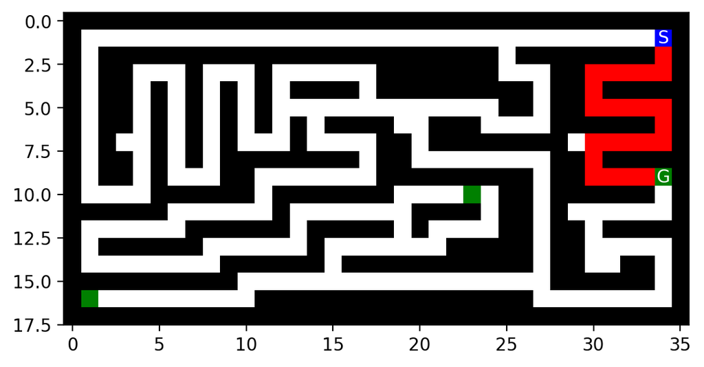

```python
class Node:
    def __init__(self, pos, parent=None, action=None, cost=0):
        self.pos = tuple(pos)    # the state; positions are (row, col)
        self.parent = parent     # reference to parent node. None means root node.
        self.action = action     # action used in the transition function (root node has None)
        self.cost = cost         # for uniform cost this is the depth

    def __str__(self):
        return f"Node - pos = {self.pos}; action = {self.action}; cost = {self.cost}"

    def get_path_from_root(self):
        """Returns nodes on the path from the root to the current node."""
        node = self
        path = [node]
        while node.parent is not None:
            node = node.parent
            path.append(node)
        path.reverse()
        return path


ACTIONS = [(-1, 0, 'North'), (1, 0, 'South'), (0, -1, 'West'), (0, 1, 'East')]

def mark_maze(maze, pos, symbol):
    """Marks the maze at a given position with a symbol."""
    maze[pos[0]][pos[1]] = symbol


def depth_limited_search(maze, node, goal, limit, visited):
    """Performs a depth-limited search."""
    if node.pos == goal:  # Check if current node is the goal
        return node.get_path_from_root()

    if limit == 0:  # If the depth limit is reached, stop expanding
        return None

    visited.add(node.pos)  # Add the current node to visited nodes

    for dx, dy, action in ACTIONS:
        next_pos = (node.pos[0] + dx, node.pos[1] + dy)  # Calculate next position
        if mh.look(maze, next_pos) != 'X' and next_pos not in visited:  # Check for valid move
            child = Node(next_pos, node, action, node.cost + 1)  # Create child node
            result = depth_limited_search(maze, child, goal, limit - 1, visited)  # Recursive call with depth limit reduced
            if result is not None:  # If a solution is found, return it
                return result

    return None


def iterative_deepening_search(maze, start, goal):
    """Performs an Iterative Deepening Search (IDS)."""
    depth = 0  # Start with a depth limit of 0 and increase iteratively
    while True:
        visited = set()  # Reset visited nodes for each new depth limit
        initial_node = Node(pos=start)
        result = depth_limited_search(maze, initial_node, goal, depth, visited)
        if result is not None:  # If a solution is found, return the path
            return result
        depth += 1  # Increment the depth limit for the next iteration


# Test the IDS on a maze
with open("medium_maze_2.txt", "r") as f:
    maze_str = f.read()

maze = mh.parse_maze(maze_str)
start = mh.find_pos(maze, what="S")
goal = mh.find_pos(maze, what="G")

print('start point is', start, 'goal point is', goal)
solution_path = iterative_deepening_search(maze, start, goal)

# Mark the solution path in the maze
if solution_path:
    for path_node in solution_path:
        if mh.look(maze, path_node.pos) != 'G' and mh.look(maze, path_node.pos) != 'S':
            mark_maze(maze, path_node.pos, 'P')
        clear_output(wait=True)
        mh.show_maze(maze)
```

When there are multiple goals, determining which one leads to the most optimal solution (in terms of path cost, nodes expanded, etc.) becomes more complex. For example, an algorithm might reach the first goal but miss a closer or cheaper-to-reach goal elsewhere in the maze. BFS and IDF will still find the shortest path to the nearest goal. DFS could find one of the goals quickly but might not necessarily be the closest or most optimal path. If we have two goals in equal distance from start both BFS and IDF will find both og the goals at the same distance but will return the first one it encounters as a solution.

## More advanced tasks to think about

### Intersection as states

Instead of defining each square as a state, use only intersections as states. Now the storage requirement is reduced, but the path length between two intersections can be different. If we use total path length measured as the number of squares as path cost, how can we make sure that BFS and iterative deepening search is optimal? Change the code to do so.

```python
# Your code/answer goes here
```

### Weighted A* search

Modify your A* search to add weights (see text book) and explore how different weights influence the result.

```python
# Your code/answer goes here
```

### Unknown Maze

What happens if the agent does not know the layout of the maze in advance? This means that the agent faces an unknown environment, where it does not know the transition function. How does the environment look then (PEAS description)? How would you implement a rational agent to solve the maze? What if the agent still has a GPS device to tell the distance to the goal?

```python
# Your code/answer goes here
```